# **GUIA DE LABORATORIO: Caso de Salud**

# **SVM: Diabetes**

## **APELLIDOS, Nombres:** MOSCOSO CHUMPITAZ, Ricardo Emmanuel

**Fecha:** Sábado 22 de Junio del 2024.

# **Laboratorio 15:** Caso práctico de aplicaciones en Salud

# **1.STANDARD LIBRARIES**

## **1.1 Captación de Fecha y Hora actual**

```python
import pandas as pd
pd.Timestamp.today().strftime('%Y-%m-%d %H:%M:%S') # Se capta la fecha y hora actual
```

```
'2024-06-25 20:05:10'
```

## **1.2 Visualización y análisis numérico**

Importar: La acción de traer funcionalidades externas.

Bibliotecas esenciales: Se refiere a matplotlib y numpy, herramientas fundamentales en el flujo de trabajo de ciencia de datos y visualización.

Para visualización: Destaca el enfoque en la creación de gráficos y representaciones visuales de datos (matplotlib).

Y análisis numérico: Enfatiza la capacidad de trabajar con arrays y realizar cálculos matemáticos eficientes (numpy).

En Python: Especifica el lenguaje de programación en el que se utilizarán estas bibliotecas.

```python
import matplotlib.pyplot as plt
import matplotlib as ml
import numpy as np
```

## **1.3 Configuración de estilo y tamaño de figuras en Matplotlib**

Configuración: Se refiere al acto de establecer preferencias específicas.

De estilo: Indica que se están modificando los aspectos visuales de los gráficos (colores, líneas, etc.).

Y tamaño de figuras: Especifica que también se ajusta el ancho y alto de las imágenes resultantes.

En Matplotlib: Aclara la biblioteca utilizada para estas tareas.

```python
from matplotlib import style
#plt.style.use('ggplot')
plt.style.use('seaborn-darkgrid')
#plt.style.use('fivethirtyeight')

from matplotlib.pylab import rcParams
rcParams['figure.figsize'] = 10,5
plt.rcParams['axes.facecolor'] = 'white'
```

```
<ipython-input-3-656e51f7f55a>:3: MatplotlibDeprecationWarning: The seaborn styles shipped by Matplotlib are deprecated since 3.6, as they no longer correspond to the styles shipped by seaborn. However, they will remain available as 'seaborn-v0_8-<style>'. Alternatively, directly use the seaborn API…
  plt.style.use('seaborn-darkgrid')
```

## **1.4 Importar Seaborn y suprimir advertencias en Python**

Importar Seaborn: Traer la biblioteca de visualización estadística para su uso.

Suprimir advertencias: Deshabilitar mensajes de advertencia que podrían aparecer durante la ejecución del código.

En Python: Especifica el lenguaje de programación en el que se realizan estas acciones.

```python
import seaborn as sns
import sys
import warnings
if not sys.warnoptions:
    warnings.simplefilter("ignore")
```

# **2. SPECIALIZED LIBRARIES:**

## **2.1Importar y Referenciar la Clase StandardScaler para Estandarización de Datos**

Este código importa la clase StandardScaler desde la biblioteca sklearn.preprocessing, que es una herramienta esencial en el preprocesamiento de datos para modelos de aprendizaje automático. StandardScaler se utiliza para estandarizar características numéricas, transformándolas para que tengan una media de cero y una desviación estándar de uno. Esta estandarización es crucial para muchos algoritmos de aprendizaje automático, ya que ayuda a evitar que las características con escalas mayores dominen a las de menor escala y mejora la convergencia de los modelos. La importación y referencia de StandardScaler en este código prepara el entorno para aplicar esta técnica de estandarización a los datos antes de su uso en el modelado.

```python
from sklearn.preprocessing import StandardScaler
StandardScaler
```

[output not shown]

[output not shown]

[output cut: 73 more lines]

[output not shown]

## **2.2 Función train_test_split para División de Conjuntos de Datos**

Este código importa la función train_test_split desde el módulo sklearn.model_selection, una herramienta fundamental en el desarrollo de modelos de aprendizaje automático. train_test_split se utiliza para dividir un conjunto de datos en dos subconjuntos: uno para entrenar el modelo (conjunto de entrenamiento) y otro para evaluar su rendimiento (conjunto de prueba). Esta división es esencial para evitar el sobreajuste, donde un modelo aprende los datos de entrenamiento demasiado bien y tiene un rendimiento deficiente en datos nuevos. La importación y referencia de train_test_split en este código prepara el entorno para aplicar esta división de datos antes de entrenar y evaluar modelos.

```python
from sklearn.model_selection import train_test_split
train_test_split
```

[output not shown]

[output not shown]

[output cut: 28 more lines]

[output not shown]

## **2.2 Importar y Referenciar la Clase SVC para Clasificación con Máquinas de Soporte Vectorial**

Este código importa la clase SVC (Support Vector Classifier) desde el módulo sklearn.svm, una herramienta poderosa en el aprendizaje automático para tareas de clasificación. SVC es un algoritmo que busca un hiperplano óptimo que separe las clases de datos con el mayor margen posible. Esta técnica es especialmente útil cuando los datos no son linealmente separables, ya que SVC puede utilizar kernels para transformar los datos a un espacio de mayor dimensión donde la separación es más fácil. La importación y referencia de SVC en este código prepara el entorno para crear y entrenar modelos de clasificación basados en máquinas de soporte vectorial.

```python
from sklearn.svm import SVC
SVC
```

[output not shown]

[output not shown]

[output cut: 165 more lines]

[output not shown]

## **2.3 Importar y Referenciar Métricas de Evaluación de Modelos de Clasificación**

Este código importa funciones clave desde el módulo sklearn.metrics para evaluar el rendimiento de modelos de clasificación. confusion_matrix crea una matriz que resume los verdaderos positivos, falsos positivos, verdaderos negativos y falsos negativos de un modelo. accuracy_score calcula la proporción de predicciones correctas. recall_score mide la capacidad del modelo para encontrar todas las instancias relevantes de una clase. f1_score combina precisión y recall en una sola métrica. Al importar y referenciar estas funciones, el código prepara el entorno para analizar y comparar diferentes modelos de clasificación en función de su rendimiento en tareas específicas.

## **2.4 Importar Métricas de Evaluación para Clasificación desde Scikit-learn**

Este código importa funciones esenciales del módulo sklearn.metrics para evaluar el rendimiento de modelos de clasificación en aprendizaje automático. confusion_matrix proporciona una tabla detallada que muestra las predicciones correctas e incorrectas del modelo, distinguiendo entre verdaderos positivos, falsos positivos, verdaderos negativos y falsos negativos. accuracy_score calcula la proporción general de predicciones correctas. recall_score mide la capacidad del modelo para identificar correctamente todas las instancias positivas de una clase, mientras que f1_score ofrece un equilibrio entre precisión (proporción de verdaderos positivos entre todas las predicciones positivas) y recall. Estas métricas son fundamentales para comprender el comportamiento de un modelo y tomar decisiones informadas sobre su optimización y selección.

```python
from sklearn.metrics import confusion_matrix,accuracy_score,recall_score,f1_score
confusion_matrix,accuracy_score,recall_score,f1_score
```

```
(<function sklearn.metrics._classification.confusion_matrix(y_true, y_pred, *, labels=None, sample_weight=None, normalize=None)>,
 <function sklearn.metrics._classification.accuracy_score(y_true, y_pred, *, normalize=True, sample_weight=None)>,
 <function sklearn.metrics._classification.recall_score(y_true, y_pred, *, labels=None, pos_label=1, average='binary', sample_weight=None, zero_division='warn')>,
 <function sklearn.metrics._classification.f1_score(y_true, y_pred, *, labels=None, pos_label=1, average='binary', sample_weight=None, zero_division='warn')>)
```

# **3. EXTRACCION DE DATOS**

```python
# Conectando con Drive
# %%time
# from google.colab import drive
# drive.mount("/content/drive")
```

## **3.1 Definir URL para Descargar el Conjunto de Datos de Diabetes**

Esta línea de código asigna la URL "https://raw.githubusercontent.com/plotly/datasets/master/diabetes.csv" a la variable url. Esta URL apunta a un archivo CSV (Comma-Separated Values) que contiene datos sobre diabetes, probablemente utilizados para análisis o modelado. Al definir esta variable, el código se prepara para descargar y acceder a este conjunto de datos, lo que permite su posterior procesamiento y análisis. Es probable que se utilice una biblioteca como pandas para leer el archivo CSV desde la URL y convertirlo en un DataFrame, una estructura de datos tabular que facilita el trabajo con los datos.

```python
# Load dataset

# url = "https://docs.google.com/spreadsheets/d/e/2PACX-1vS63SEX5gwlZQNTXeMkkahiqpwRd77Nl79SHNulq3dj2sf_nAv1EXX7chQ7630YpHVzbeMNSt2Q4D23/pub?output=csv"
url = "https://raw.githubusercontent.com/plotly/datasets/master/diabetes.csv"
url
```

```
'https://raw.githubusercontent.com/plotly/datasets/master/diabetes.csv'
```

## **3.2 Leer Datos de Diabetes desde una URL y Mostrar las Primeras Filas**

```python
df = pd.read_csv( url )#df
#df_pib = pd.read_csv(url, sep="," , index_col=0)
df.head(2)
```

|  | Pregnancies | Glucose | BloodPressure | SkinThickness | Insulin | BMI | DiabetesPedigreeFunction | Age | Outcome |
| --- | --- | --- | --- | --- | --- | --- | --- | --- | --- |
| 0 | 6 | 148 | 72 | 35 | 0 | 33.6 | 0.627 | 50 | 1 |
| 1 | 1 | 85 | 66 | 29 | 0 | 26.6 | 0.351 | 31 | 0 |

# **3.3 E.D.A - Exploratory Data Analysis:** Análisis Estadística Descriptiva

```python
## DATAFRAME de Pandas
print(type( df ))
display(len( df )) # shape len
display( df.info() )
display(df.describe())
display(df.sample(2))
display( df ) # .head(3) .tail(2)
```

```
<class 'pandas.core.frame.DataFrame'>
```

```
768
```

```
<class 'pandas.core.frame.DataFrame'>
RangeIndex: 768 entries, 0 to 767
Data columns (total 9 columns):
 #   Column                    Non-Null Count  Dtype
---  ------                    --------------  -----
 0   Pregnancies               768 non-null    int64
 1   Glucose                   768 non-null    int64
 2   BloodPressure             768 non-null    int64
 3   SkinThickness             768 non-null    int64
 4   Insulin                   768 non-null    int64
 5   BMI                       768 non-null    float64
 6   DiabetesPedigreeFunction  768 non-null    float64
 7   Age                       768 non-null    int64
 8   Outcome                   768 non-null    int64
dtypes: float64(2), int64(7)
memory usage: 54.1 KB
```

```
None
```

|  | Pregnancies | Glucose | BloodPressure | SkinThickness | Insulin | BMI | DiabetesPedigreeFunction | Age | Outcome |
| --- | --- | --- | --- | --- | --- | --- | --- | --- | --- |
| count | 768.000000 | 768.000000 | 768.000000 | 768.000000 | 768.000000 | 768.000000 | 768.000000 | 768.000000 | 768.000000 |
| mean | 3.845052 | 120.894531 | 69.105469 | 20.536458 | 79.799479 | 31.992578 | 0.471876 | 33.240885 | 0.348958 |
| std | 3.369578 | 31.972618 | 19.355807 | 15.952218 | 115.244002 | 7.884160 | 0.331329 | 11.760232 | 0.476951 |
| min | 0.000000 | 0.000000 | 0.000000 | 0.000000 | 0.000000 | 0.000000 | 0.078000 | 21.000000 | 0.000000 |
| 25% | 1.000000 | 99.000000 | 62.000000 | 0.000000 | 0.000000 | 27.300000 | 0.243750 | 24.000000 | 0.000000 |
| 50% | 3.000000 | 117.000000 | 72.000000 | 23.000000 | 30.500000 | 32.000000 | 0.372500 | 29.000000 | 0.000000 |
| 75% | 6.000000 | 140.250000 | 80.000000 | 32.000000 | 127.250000 | 36.600000 | 0.626250 | 41.000000 | 1.000000 |
| max | 17.000000 | 199.000000 | 122.000000 | 99.000000 | 846.000000 | 67.100000 | 2.420000 | 81.000000 | 1.000000 |

|  | Pregnancies | Glucose | BloodPressure | SkinThickness | Insulin | BMI | DiabetesPedigreeFunction | Age | Outcome |
| --- | --- | --- | --- | --- | --- | --- | --- | --- | --- |
| 468 | 8 | 120 | 0 | 0 | 0 | 30.0 | 0.183 | 38 | 1 |
| 454 | 2 | 100 | 54 | 28 | 105 | 37.8 | 0.498 | 24 | 0 |

|  | Pregnancies | Glucose | BloodPressure | SkinThickness | Insulin | BMI | DiabetesPedigreeFunction | Age | Outcome |
| --- | --- | --- | --- | --- | --- | --- | --- | --- | --- |
| 0 | 6 | 148 | 72 | 35 | 0 | 33.6 | 0.627 | 50 | 1 |
| 1 | 1 | 85 | 66 | 29 | 0 | 26.6 | 0.351 | 31 | 0 |
| 2 | 8 | 183 | 64 | 0 | 0 | 23.3 | 0.672 | 32 | 1 |
| 3 | 1 | 89 | 66 | 23 | 94 | 28.1 | 0.167 | 21 | 0 |
| 4 | 0 | 137 | 40 | 35 | 168 | 43.1 | 2.288 | 33 | 1 |
| ... | ... | ... | ... | ... | ... | ... | ... | ... | ... |
| 763 | 10 | 101 | 76 | 48 | 180 | 32.9 | 0.171 | 63 | 0 |
| 764 | 2 | 122 | 70 | 27 | 0 | 36.8 | 0.340 | 27 | 0 |
| 765 | 5 | 121 | 72 | 23 | 112 | 26.2 | 0.245 | 30 | 0 |
| 766 | 1 | 126 | 60 | 0 | 0 | 30.1 | 0.349 | 47 | 1 |
| 767 | 1 | 93 | 70 | 31 | 0 | 30.4 | 0.315 | 23 | 0 |

768 rows × 9 columns

## **3.4 Distribution of Glucose Levels by Outcome**

Utilizamos matplotlib para crear un diagrama de caja que compara la distribución de los niveles de glucosa en dos grupos: individuos con resultado 0 (posiblemente sin diabetes) y resultado 1 (posiblemente con diabetes). Primero, filtra los datos del DataFrame df en dos subconjuntos basados en la columna Outcome. Luego, genera un diagrama de caja para cada subconjunto, mostrando la mediana, cuartiles, valores atípicos y rango intercuartil de los niveles de glucosa. Los ejes están etiquetados como 'Outcome' y 'Glucose Level', y el título indica claramente el propósito del gráfico. El guion bajo (_) se utiliza para suprimir la salida de texto que matplotlib generaría al asignar el título. Este gráfico permite una rápida evaluación visual de las diferencias en los niveles de glucosa entre los dos grupos.

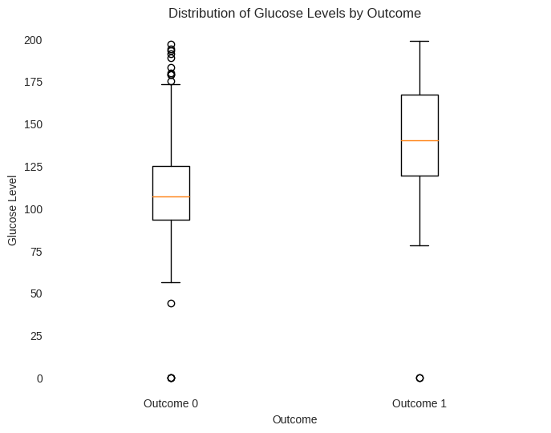

```python
import matplotlib.pyplot as plt

plt.figure(figsize=(8, 6))
plt.boxplot([df[df['Outcome'] == 0]['Glucose'], df[df['Outcome'] == 1]['Glucose']], labels=['Outcome 0', 'Outcome 1'])
plt.xlabel('Outcome')
plt.ylabel('Glucose Level')
_ = plt.title('Distribution of Glucose Levels by Outcome')
```

Se muestra un gráfico de caja que compara la distribución de los niveles de glucosa en sangre entre dos grupos: "Outcome 0" y "Outcome 1". El eje vertical representa los niveles de glucosa, mientras que el eje horizontal representa los dos grupos.

Observaciones clave:

Rango intercuartil (IQR): El IQR (la caja en sí) es más grande en el grupo "Outcome 1", lo que indica una mayor variabilidad en los niveles de glucosa en ese grupo en comparación con el grupo "Outcome 0".

## **3.5 Blood Pressure vs BMI by Age Group**

Generamos un gráfico de dispersión utilizando Matplotlib para visualizar la relación entre el índice de masa corporal (IMC) y la presión arterial de los individuos en el conjunto de datos de diabetes. La edad de cada individuo se representa mediante un esquema de color (mapa de color 'viridis'), donde los colores más fríos indican edades más jóvenes y los colores más cálidos, edades más avanzadas. El gráfico incluye una barra de color que explica la escala de colores utilizada para representar la edad. Los ejes están etiquetados como 'BMI' y 'Blood Pressure', y el título describe claramente el propósito del gráfico: mostrar la relación entre estas dos variables y cómo varía según la edad. El guion bajo (_) se utiliza para suprimir la salida de texto que matplotlib generaría al asignar el título. Este gráfico permite una rápida identificación de patrones y tendencias en los datos, como si existe una correlación entre IMC y presión arterial, y cómo esta relación podría cambiar con la edad.

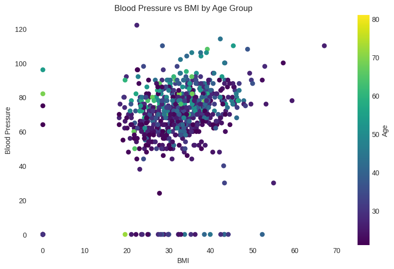

```python
import matplotlib.pyplot as plt

plt.figure(figsize=(10, 6))
plt.scatter(df['BMI'], df['BloodPressure'], c=df['Age'], cmap='viridis')
plt.colorbar(label='Age')
plt.xlabel('BMI')
plt.ylabel('Blood Pressure')
_ = plt.title('Blood Pressure vs BMI by Age Group')
```

La imagen muestra un gráfico de dispersión que representa la relación entre el índice de masa corporal (IMC) y la presión arterial en un grupo de individuos. Cada punto en el gráfico representa a una persona, y la posición del punto indica su IMC (en el eje x) y su presión arterial (en el eje y).

El color de cada punto representa la edad de la persona, según la barra de color a la derecha del gráfico. Los colores más cálidos (amarillo, verde) indican edades más avanzadas, mientras que los colores más fríos (azul, morado) indican edades más jóvenes.

# **4. TRANSFORMACION Y/O LIMPIEZA - PRE-PROCESAMIENTO:** ETL

## **4.1 Particionar X & Y**

Creamos una copia exacta del DataFrame df y la asigna a una nueva variable. llamada data.

```python
data = df.copy()
```

Creamos una matriz NumPy (X) a partir de los datos del DataFrame data. Utiliza la indexación iloc[:,:-1] para seleccionar todas las filas y todas las columnas excepto la última. Luego, .values extrae los valores numéricos de estas columnas y los convierte en un array NumPy. Esta matriz X se utilizará como conjunto de características para entrenar un modelo de aprendizaje automático, donde cada fila representa una muestra y cada columna representa una característica. La última columna del DataFrame original contiene la variable objetivo que el modelo intentará predecir.

```python
X = np.array(data.iloc[:,:-1].values)
```

```python
## ARRAY de Numpy
print(type( X ))
display(len( X )) # shape len
display( X[:3] ) # .head(3) .tail(2) [:3]
```

```
<class 'numpy.ndarray'>
```

```
768
```

```
array([[  6.   , 148.   ,  72.   ,  35.   ,   0.   ,  33.6  ,   0.627,
         50.   ],
       [  1.   ,  85.   ,  66.   ,  29.   ,   0.   ,  26.6  ,   0.351,
         31.   ],
       [  8.   , 183.   ,  64.   ,   0.   ,   0.   ,  23.3  ,   0.672,
         32.   ]])
```

Creamos un array NumPy (Y) a partir de la última columna del DataFrame data. Utiliza la indexación iloc[:,-1] para seleccionar todas las filas y solo la última columna. Luego, .values extrae los valores de esta columna y los convierte en un array NumPy. Este array Y se utilizará como conjunto de etiquetas o variable objetivo para entrenar un modelo de aprendizaje automático, donde cada elemento corresponde a la etiqueta o valor que el modelo intentará predecir para cada muestra en el conjunto de características X.

```python
Y = np.array(data.iloc[:,-1].values)
```

```python
## ARRAY de Numpy
print(type( Y ))
new_var = len( Y )
display(new_var) # shape len
display( Y[:3] ) # .head(3) .tail(2) [:3]
```

```
<class 'numpy.ndarray'>
```

```
768
```

```
array([1, 0, 1])
```

La función train_test_split de la biblioteca scikit-learn se usará para dividir los datos en conjuntos de entrenamiento y prueba. X (la matriz de características) e Y (el vector de etiquetas) se dividen aleatoriamente en cuatro conjuntos: train_x y trainy (80% de los datos) se utilizarán para entrenar el modelo de aprendizaje automático, mientras que test_x y testy (20% de los datos) se reservarán para evaluar su rendimiento en datos no vistos durante el entrenamiento. El parámetro random_state=0 garantiza que la división sea reproducible, generando siempre la misma división de datos si se vuelve a ejecutar el código. Esta división es fundamental para evitar el sobreajuste y obtener una estimación más precisa del rendimiento del modelo en datos nuevos.

```python
train_x, test_x, trainy, testy = train_test_split(X,Y,test_size=0.20,random_state=0)
```

Examinamos la variable train_x, que normalmente contiene datos de entrada para entrenar un modelo de aprendizaje automático. Primero, revela el tipo de datos de train_x (como una matriz NumPy o un DataFrame de Pandas). Luego, se muestra la cantidad de filas (muestras de datos) o elementos en train_x. Finalmente, proporciona una vista previa de las primeras 3 filas, lo que permite verificar la estructura y el contenido de los datos antes de continuar con el análisis o el entrenamiento del modelo.

```python
## ARRAY de Numpy
print(type( train_x ))
display(len( train_x )) # shape len
display( train_x[:3] ) # .head(3) .tail(2) [:3]
```

```
<class 'numpy.ndarray'>
```

```
614
```

```
array([[7.00e+00, 1.50e+02, 7.80e+01, 2.90e+01, 1.26e+02, 3.52e+01,
        6.92e-01, 5.40e+01],
       [4.00e+00, 9.70e+01, 6.00e+01, 2.30e+01, 0.00e+00, 2.82e+01,
        4.43e-01, 2.20e+01],
       [0.00e+00, 1.65e+02, 9.00e+01, 3.30e+01, 6.80e+02, 5.23e+01,
        4.27e-01, 2.30e+01]])
```

## **4.2 Escalar X & Y**

Realizamos el preprocesamiento de datos de entrenamiento (train_x) y prueba (test_x) mediante la estandarización de características con StandardScaler. Luego, verifica que los datos transformados (trainx) sean una matriz NumPy, muestra su longitud (número de filas) y las primeras 3 filas para una inspección rápida. Esto asegura que los datos estén en un formato adecuado y listos para ser utilizados en el entrenamiento de modelos de aprendizaje automático.

```python
StandardScaler
```

[output not shown]

[output not shown]

[output cut: 73 more lines]

[output not shown]

```python
sc = StandardScaler()
sc
```

```
StandardScaler()
```

```python
trainx, testx = sc.fit_transform(train_x), sc.fit_transform(test_x)
```

```python
## ARRAY de Numpy
print(type( trainx ))
display(len( trainx )) # shape len
display( trainx[:3] ) # .head(3) .tail(2) [:3]
```

```
<class 'numpy.ndarray'>
```

```
614
```

```
array([[ 0.90832902,  0.91569367,  0.44912368,  0.52222619,  0.3736349 ,
         0.37852648,  0.67740401,  1.69955804],
       [ 0.03644676, -0.75182191, -0.47230103,  0.14814855, -0.69965674,
        -0.50667229, -0.07049698, -0.96569189],
       [-1.12606292,  1.38763205,  1.06340683,  0.77161128,  5.09271083,
         2.54094063, -0.11855487, -0.88240283]])
```

```python
## ARRAY de Numpy
print(type( testx ))
display(len( testx )) # shape len
display( testx[:3] ) # .head(3) .tail(2) [:3]
```

```
<class 'numpy.ndarray'>
```

```
154
```

```
array([[-0.89295432,  2.39507259,  0.39763774,  1.46777905, -0.66926158,
         1.52657475,  2.78935129, -0.93064283],
       [-0.56553774, -0.42589245,  0.2898275 ,  0.6313163 ,  0.28030801,
         0.31944116, -0.27698825, -0.83598035],
       [ 0.08929543, -1.37643502, -0.35703388, -1.29898237, -0.66926158,
         0.37136088, -0.31725331, -0.64665539]])
```

```python
print("For X : Training : {} ; Testing : {}".format(trainx.shape,testx.shape))
```

```
For X : Training : (614, 8) ; Testing : (154, 8)
```

```python
print("\nFor Y : Training : {} ; Testing : {}".format(trainy.shape,testy.shape))
```

```
For Y : Training : (614,) ; Testing : (154,)
```

# **4.3 Análisis Bivariado y Multivariado:** Análisis de cada variable "x(i)" versus la variable target (objetivo) "y"

Generamos gráficos de pares (pairplot) utilizando la biblioteca Seaborn. Este gráfico de pares visualiza la relación entre cada par de variables en el conjunto de datos data, mostrando histogramas en la diagonal y diagramas de dispersión en las celdas fuera de la diagonal.

La parte clave aquí es hue='Outcome', que colorea los puntos en los gráficos según los valores de la variable 'Outcome'. Esto permite analizar visualmente cómo la variable 'Outcome' (que a menudo representa una variable objetivo o de interés) se relaciona con otras variables en el conjunto de datos.

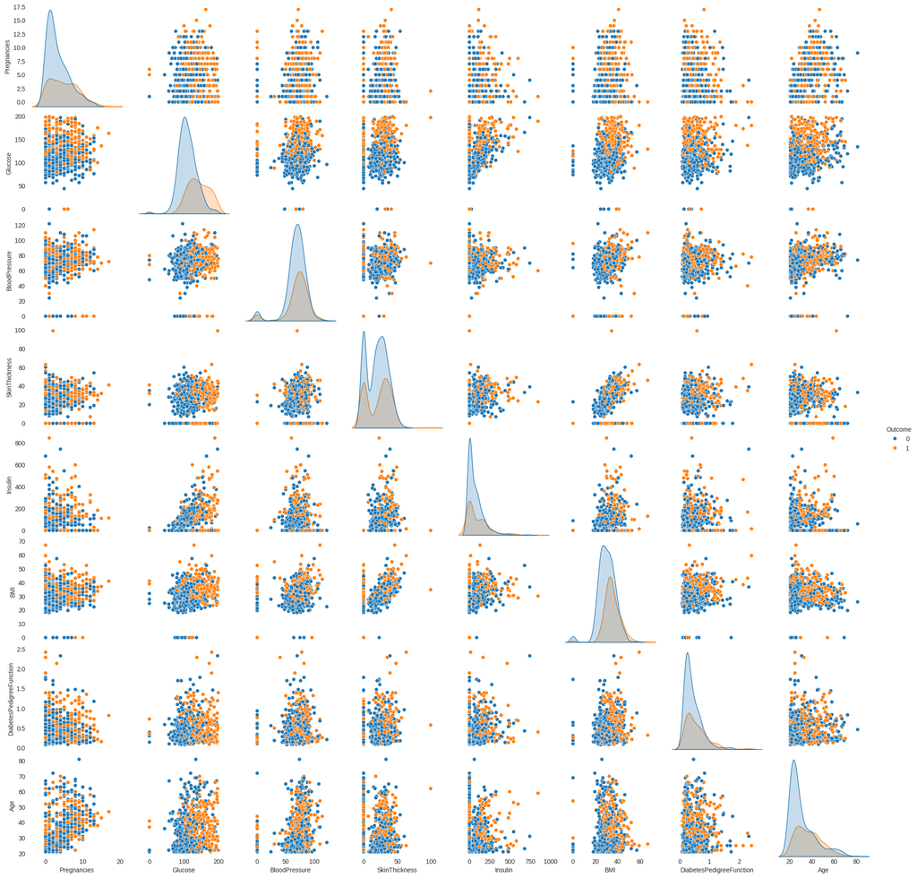

```
CPU times: user 30.6 s, sys: 943 ms, total: 31.6 s
Wall time: 43.1 s
```

```python
%%time
sns.pairplot(data,hue='Outcome')
plt.show()
```

# **5. MODELO 1:** Modelamiento: Crear modelo, FIT (Ajustar, Entrenar), PREDICT (generar valores ajustados y/o predicción)

Creamos un modelo de clasificación de vectores de soporte (SVC) llamado Modelo_SVC_v1, configurado con un kernel de función de base radial para manejar relaciones no lineales en los datos, un valor de regularización C de 1 para equilibrar el margen y el error de clasificación, y un valor gamma automático que se ajusta a los datos. Este modelo está listo para ser entrenado con datos etiquetados para aprender a clasificar nuevas muestras en diferentes categorías.

```python
 Modelo_SVC_v1 = SVC(kernel='rbf',C=1,gamma='auto')
 Modelo_SVC_v1
```

```
SVC(C=1, gamma='auto')
```

Entrenamos un modelo de clasificación de vectores de soporte previamente definido (Modelo_SVC_v1) utilizando datos de entrenamiento (trainx y trainy) y mide el tiempo que tarda este proceso.

```python
 %%time
 Modelo_SVC_v1.fit( trainx, trainy)
```

```
CPU times: user 19.1 ms, sys: 1 ms, total: 20.1 ms
Wall time: 20.3 ms
```

```
SVC(C=1, gamma='auto')
```

Usamos el modelo de clasificación de vectores de soporte (SVC) previamente entrenado, llamado Modelo_SVC_v1, para hacer predicciones sobre los datos de prueba (testx). El resultado, almacenado en la variable y_test_predicho, es un conjunto de etiquetas predichas para cada muestra en el conjunto de datos de prueba. Estas etiquetas predichas representan la clasificación que el modelo asigna a cada muestra según los patrones aprendidos durante el entrenamiento.

```python
 y_test_predicho = Modelo_SVC_v1.predict(testx)
```

```python
## ARRAY de Numpy
print(type( y_test_predicho ))
display(len( y_test_predicho )) # shape len
display( y_test_predicho[:3] ) # .head(3) .tail(2) [:3]
```

```
<class 'numpy.ndarray'>
```

```
154
```

```
array([1, 0, 0])
```

# **6. EVALUAR MODELOS:** Métricas

evaluamos el rendimiento de un modelo de clasificación (SVC) con un valor de C=1, calculando e imprimiendo tres métricas clave: exactitud (accuracy), sensibilidad (recall) y puntuación F1 (f1 score). Estas métricas proporcionan información sobre la precisión general del modelo, su capacidad para identificar correctamente los casos positivos y un equilibrio entre ambos aspectos, respectivamente.

```python
accuracy = (accuracy_score(testy, y_test_predicho ))
recall = (recall_score(testy, y_test_predicho ))
f1 = (f1_score(testy, y_test_predicho ))
print("For C = 1 METRICAS: accuracy:", accuracy, " recall:",recall, " f1:",f1,"\n")
```

```
For C = 1 METRICAS: accuracy: 0.8051948051948052  recall: 0.5957446808510638  f1: 0.6511627906976744
```

El resultado obtenido indica lo siguiente sobre el rendimiento del modelo de clasificación con un valor de C=1:

Exactitud (Accuracy): 0.805 El modelo clasifica correctamente el 80.5% de las muestras en el conjunto de datos de prueba. Esto significa que aproximadamente 8 de cada 10 predicciones son correctas.

Sensibilidad (Recall): 0.596 El modelo es capaz de identificar correctamente el 59.6% de los casos positivos reales. Es decir, de todas las muestras que realmente pertenecen a la clase positiva, el modelo solo detecta correctamente el 59.6%.

Puntuación F1 (F1 Score): 0.651 Esta métrica combina la precisión y la sensibilidad en un solo valor, indicando un equilibrio entre ambas. Un valor de 0.651 sugiere que, aunque el modelo tiene una buena exactitud general, podría tener dificultades para identificar todos los casos positivos.

Con En Python, confusion_matrix(testy, y_test_predicho) generamos una tabla que compara las etiquetas reales (testy) con las predichas por un modelo (y_test_predicho). Esta tabla, llamada matriz de confusión, muestra cuántas predicciones fueron correctas (verdaderos positivos y negativos) e incorrectas (falsos positivos y negativos) para cada clase, revelando los puntos fuertes y débiles del modelo y guiando posibles mejoras.

```python
confusion_matrix( testy , y_test_predicho )
```

```
array([[96, 11],
       [19, 28]])
```

# **7. MODELO(S):** Modelamiento: Crear modelo, FIT (Ajustar, Entrenar), PREDICT (generar valores ajustados y/o predicción)

Bucle para ajustar varios clasificadores SVM con diferentes valores de un parámetro de regularización (C).

```python
m=50
accuracy_list = []
recall_list, f1_list = [], []
```

```python
%%time
for i in range(1,m):
    svm_c = SVC(kernel='rbf',C=i, gamma='auto')
    svm_c.fit(trainx,trainy)
    y_pred_i = svm_c.predict(testx)

    # METRICAS
    accuracy_list.append(accuracy_score(testy,y_pred_i))
    recall_list.append(recall_score(testy,y_pred_i))
    f1_list.append(f1_score(testy,y_pred_i))
    print("For C = {},".format(i),"METRICAS: accuracy:", accuracy_list[i-1], " recall:",recall_list[i-1], " f1:",f1_list[i-1],"\n")
    print("For C = {},".format(i),"confusion matrix : \n",confusion_matrix(testy,y_pred_i),"\n")
```

```
For C = 1, METRICAS: accuracy: 0.8051948051948052  recall: 0.5957446808510638  f1: 0.6511627906976744

For C = 1, confusion matrix :
 [[96 11]
 [19 28]]

For C = 2, METRICAS: accuracy: 0.7792207792207793  recall: 0.5531914893617021  f1: 0.6046511627906976

For C = 2, confusion matrix :
 [[94 13]
 [21 26]]

For C = 3, METRICAS: accuracy: 0.7727272727272727  recall: 0.574468085106383  f1: 0.6067415730337079

For C = 3, confusion matrix :
 [[92 15]
 [20 27]]

For C = 4, METRICAS: accuracy: 0.7532467532467533  recall: 0.5319148936170213  f1: 0.5681818181818181

For C = 4, confusion matrix :
 [[91 16]
 [22 25]]

For C = 5, METRICAS: accuracy: 0.7532467532467533  recall: 0.5531914893617021  f1: 0.5777777777777778

For C = 5, confusion matrix :
 [[90 17]
 [21 26]]

For C = 6, METRICAS: accuracy: 0.7727272727272727  recall: 0.6170212765957447  f1: 0.6236559139784946

For C = 6, confusion matrix :
 [[90 17]
 [18 29]]

For C = 7, METRICAS: accuracy: 0.7727272727272727  recall: 0.6170212765957447  f1: 0.6236559139784946

For C = 7, confusion matrix :
 [[90 17]
```

[output cut: 241 more lines]

```

For C = 48, METRICAS: accuracy: 0.7467532467532467  recall: 0.574468085106383  f1: 0.5806451612903226

For C = 48, confusion matrix :
 [[88 19]
 [20 27]]

For C = 49, METRICAS: accuracy: 0.7467532467532467  recall: 0.574468085106383  f1: 0.5806451612903226

For C = 49, confusion matrix :
 [[88 19]
 [20 27]]

CPU times: user 1.94 s, sys: 46.4 ms, total: 1.98 s
Wall time: 2.05 s
```

Los resultados experimentales muestran que el modelo de clasificación de vectores de soporte (SVC), al variar el parámetro de regularización C entre 41 y 49, mantiene un rendimiento constante. La exactitud (accuracy) oscila alrededor del 74-75%, indicando que el modelo acierta en aproximadamente tres de cada cuatro predicciones. Sin embargo, la sensibilidad (recall) se mantiene en un 57%, lo que sugiere que el modelo tiene dificultades para identificar correctamente todos los casos positivos. La puntuación F1, que busca un equilibrio entre precisión y sensibilidad, también se mantiene estable en un rango del 58%.

Usamos display(accuracy_list), una instrucción utilizada para mostrar el contenido de la variable accuracy_list de una manera más visual y estructurada que un simple print().

```python
display(accuracy_list)
```

```
[0.8051948051948052,
 0.7792207792207793,
 0.7727272727272727,
 0.7532467532467533,
 0.7532467532467533,
 0.7727272727272727,
 0.7727272727272727,
 0.7727272727272727,
 0.7727272727272727,
 0.7727272727272727,
 0.7857142857142857,
 0.7857142857142857,
 0.7727272727272727,
 0.7792207792207793,
 0.7792207792207793,
 0.7792207792207793,
 0.7727272727272727,
 0.7792207792207793,
 0.7857142857142857,
 0.7922077922077922,
 0.7922077922077922,
 0.7922077922077922,
 0.7857142857142857,
 0.7857142857142857,
 0.7857142857142857,
 0.7922077922077922,
 0.7857142857142857,
 0.7857142857142857,
 0.7792207792207793,
 0.7792207792207793,
 0.7662337662337663,
 0.7597402597402597,
 0.7532467532467533,
 0.7532467532467533,
 0.7532467532467533,
 0.7532467532467533,
 0.7532467532467533,
 0.7532467532467533,
 0.7532467532467533,
 0.7532467532467533,
 0.7532467532467533,
 0.7532467532467533,
 0.7467532467532467,
 0.7467532467532467,
 0.7467532467532467,
 0.7467532467532467,
 0.7467532467532467,
 0.7467532467532467,
 0.7467532467532467]
```

```python
#display(recall_list)
#display(f1_list)
```

## **7.1 Creación de un Eje X para Visualización de Datos**

El código Python x_axis = [i for i in range(1, m)] genera una lista de números enteros consecutivos desde 1 hasta m-1. Esta lista, almacenada en la variable x_axis, se utiliza comúnmente como eje X en gráficos y visualizaciones de datos, proporcionando una escala numérica para representar los puntos de datos correspondientes en el eje Y.

```python
x_axis = [i for i in range(1,m)]
#x_axis
```

```python
len(accuracy_list)
```

```
49
```

## **7.2 Gráfico Comparativo de Métricas de Rendimiento en Función del Parámetro C en un Modelo de Clasificación**

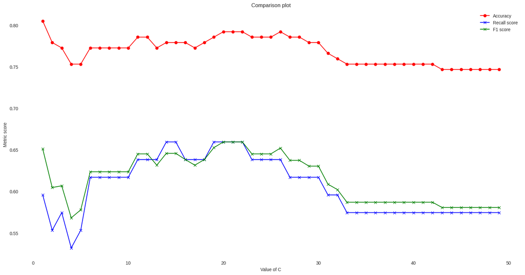

```python
plt.figure(figsize=(20,10))
plt.plot(x_axis,accuracy_list,color='red',marker='o',label='Accuracy')
plt.plot(x_axis,recall_list,color='blue',marker='x',label='Recall score')
plt.plot(x_axis,f1_list,color='green',marker='x',label='F1 score')
plt.legend()
plt.xlabel("Value of C")
plt.ylabel("Metric score")
plt.title("Comparison plot")
plt.show()
```

El gráfico muestra cómo varían la precisión (accuracy), la sensibilidad (recall) y la puntuación F1 de un modelo de clasificación (posiblemente un Support Vector Machine o SVM) a medida que se ajusta el parámetro de regularización C. Este parámetro controla el equilibrio entre maximizar el margen de separación entre clases y minimizar el error de clasificación.

F1 score (puntuación F1): Es una medida que combina precisión y sensibilidad. En este caso, la puntuación F1 alcanza su punto máximo alrededor de C=20, lo que sugiere que este valor podría ser un buen compromiso entre precisión y sensibilidad.

## **7.3 Identificación del Parámetro C Óptimo para la Máxima Precisión**

Identificamos y mostramos el valor óptimo del parámetro C que produjo la mayor precisión en un modelo de clasificación (como un SVM). Primero, utiliza np.argmax() para encontrar el índice donde ocurre la precisión máxima en la lista accuracy_list. Luego, ajusta el índice sumando 1 para obtener el valor correspondiente de C (ya que los índices comienzan en 0). Finalmente, se imprime un mensaje informativo que indica el valor óptimo de C y la precisión máxima alcanzada.

```python
print("METRIC : ACCURACY\nHighest accuracy is obtained for C = {}, and the accuracy is = {}"\
      .format(np.argmax(accuracy_list)+1,accuracy_list[np.argmax(accuracy_list)]))
```

```
METRIC : ACCURACY
Highest accuracy is obtained for C = 1, and the accuracy is = 0.8051948051948052
```

El análisis de rendimiento del modelo SVC revindica que el valor óptimo del parámetro de regularización C para maximizar la precisión (accuracy) es 1, alcanzando un valor de 80.52%. Esto significa que el modelo, con esta configuración, clasifica correctamente el 80.52% de las muestras en el conjunto de datos de prueba.

## **7.4 Identificación del Parámetro C Óptimo para la Máxima Sensibilidad (Recall) en un Modelo de Clasificación:**

Determinamos el valor óptimo del parámetro de regularización C que maximiza la sensibilidad (recall) en un modelo de clasificación. La sensibilidad es crucial en aplicaciones donde la identificación correcta de casos positivos es fundamental, como en diagnósticos médicos. El código encuentra el índice del valor máximo de recall en la lista recall_list, ajusta este índice para corresponder al valor de C y luego imprime un mensaje claro que indica el valor óptimo de C y la sensibilidad máxima lograda.

```python
print("\nMETRIC : RECALL SCORE\nHighest RECALL is obtained for C = {}, and the accuracy is = {}"\
      .format(np.argmax(recall_list)+1,accuracy_list[np.argmax(recall_list)]))
```

```
METRIC : RECALL SCORE
Highest RECALL is obtained for C = 14, and the accuracy is = 0.7792207792207793
```

Los resultados indican que el valor óptimo del parámetro de regularización C para maximizar la sensibilidad (recall) es 14. Sin embargo, es importante notar que la precisión (accuracy) correspondiente a este valor de C es 0.779, lo que indica un equilibrio entre la capacidad del modelo para identificar correctamente los casos positivos y su precisión general en todas las predicciones. Este resultado sugiere que, aunque el modelo es efectivo para detectar la mayoría de los casos positivos, puede haber un pequeño margen de error en la clasificación general.

## **7.5 Identificación del Parámetro C Óptimo para la Máxima Puntuación F1**

Identificamos el valor óptimo del parámetro C en un modelo de clasificación que maximiza la puntuación F1, una métrica clave que equilibra la precisión y la sensibilidad. Al encontrar el índice con la puntuación F1 más alta en la lista f1_list y ajustarlo para corresponder al valor correcto de C, el código determina la configuración óptima para el modelo y comunica este valor junto con la puntuación F1 alcanzada. Esta información es esencial para optimizar el rendimiento del modelo, especialmente en escenarios donde tanto la precisión como la sensibilidad son importantes.

```python
print("\nMETRIC : F1 SCORE\nHighest F1 SCORE is obtained for C = {}, and the accuracy is = {}"\
      .format(np.argmax(f1_list)+1,accuracy_list[np.argmax(f1_list)]))
```

```
METRIC : F1 SCORE
Highest F1 SCORE is obtained for C = 20, and the accuracy is = 0.7922077922077922
```

# **7.6 Calcular la puntuación combinada con la SUMA PONDERADA:**

### Calcular la puntuación combinada

Calculamnos una métrica de rendimiento combinada para un modelo de clasificación. Se utilizará una lista de comprensión para iterar simultáneamente sobre tres listas: accuracy_list (precisión), recall_list (sensibilidad) y f1_list (puntuación F1). Para cada conjunto de valores de estas métricas, se calculrá un puntaje ponderado donde la precisión tiene un peso de 0.4, y tanto la sensibilidad como la puntuación F1 tienen pesos de 0.3. Estos puntajes ponderados se suman para obtener la puntuación combinada final, que se almacena en la lista combined_score. Esta puntuación combinada proporciona una evaluación más completa del rendimiento del modelo, considerando no solo la precisión general, sino también su capacidad para identificar correctamente los casos positivos y el equilibrio entre ambas métricas.

```python
combined_score = [(0.4 * acc) + (0.3 * rec) + (0.3 * f1) for acc, rec, f1 in zip(accuracy_list, recall_list, f1_list)]
#combined_score
```

### Crear el DataFrame

Creamos un DataFrame de Pandas, una estructura de datos tabular, para organizar y visualizar los resultados de la evaluación de un modelo de clasificación. Primero, define un diccionario llamado data_metricas, donde las claves son los nombres de las métricas ("Accuracy", "Recall", "F1-Score", "Combined Score") y los valores son las listas correspondientes que contienen los resultados para diferentes valores del hiperparámetro C. Luego, utiliza este diccionario para construir el DataFrame df_metricas, estableciendo un índice numérico que va desde 1 hasta la cantidad de elementos en las listas de métricas. El resultado es una tabla ordenada que muestra cómo varían las diferentes métricas de rendimiento en función del valor de C, lo cual es útil para analizar y comparar el desempeño del modelo bajo diferentes configuraciones.

```python
data_metricas = {'Accuracy': accuracy_list, 'Recall': recall_list, 'F1-Score': f1_list, 'Combined Score': combined_score}
df_metricas = pd.DataFrame(data_metricas, index=range(1, len(accuracy_list) + 1))
df_metricas
```

|  | Accuracy | Recall | F1-Score | Combined Score |
| --- | --- | --- | --- | --- |
| 1 | 0.805195 | 0.595745 | 0.651163 | 0.696150 |
| 2 | 0.779221 | 0.553191 | 0.604651 | 0.659041 |
| 3 | 0.772727 | 0.574468 | 0.606742 | 0.663454 |
| 4 | 0.753247 | 0.531915 | 0.568182 | 0.631328 |
| 5 | 0.753247 | 0.553191 | 0.577778 | 0.640589 |
| 6 | 0.772727 | 0.617021 | 0.623656 | 0.681294 |
| 7 | 0.772727 | 0.617021 | 0.623656 | 0.681294 |
| 8 | 0.772727 | 0.617021 | 0.623656 | 0.681294 |
| 9 | 0.772727 | 0.617021 | 0.623656 | 0.681294 |
| 10 | 0.772727 | 0.617021 | 0.623656 | 0.681294 |
| 11 | 0.785714 | 0.638298 | 0.645161 | 0.699323 |
| 12 | 0.785714 | 0.638298 | 0.645161 | 0.699323 |
| 13 | 0.772727 | 0.638298 | 0.631579 | 0.690054 |
| 14 | 0.779221 | 0.659574 | 0.645833 | 0.703311 |
| 15 | 0.779221 | 0.659574 | 0.645833 | 0.703311 |
| 16 | 0.779221 | 0.638298 | 0.638298 | 0.694667 |
| 17 | 0.772727 | 0.638298 | 0.631579 | 0.690054 |
| 18 | 0.779221 | 0.638298 | 0.638298 | 0.694667 |
| 19 | 0.785714 | 0.659574 | 0.652632 | 0.707948 |
| 20 | 0.792208 | 0.659574 | 0.659574 | 0.712628 |
| 21 | 0.792208 | 0.659574 | 0.659574 | 0.712628 |
| 22 | 0.792208 | 0.659574 | 0.659574 | 0.712628 |
| 23 | 0.785714 | 0.638298 | 0.645161 | 0.699323 |
| 24 | 0.785714 | 0.638298 | 0.645161 | 0.699323 |
| 25 | 0.785714 | 0.638298 | 0.645161 | 0.699323 |
| 26 | 0.792208 | 0.638298 | 0.652174 | 0.704025 |
| 27 | 0.785714 | 0.617021 | 0.637363 | 0.690601 |
| 28 | 0.785714 | 0.617021 | 0.637363 | 0.690601 |
| 29 | 0.779221 | 0.617021 | 0.630435 | 0.685925 |
| 30 | 0.779221 | 0.617021 | 0.630435 | 0.685925 |
| 31 | 0.766234 | 0.595745 | 0.608696 | 0.667826 |
| 32 | 0.759740 | 0.595745 | 0.602151 | 0.663265 |
| 33 | 0.753247 | 0.574468 | 0.586957 | 0.649726 |
| 34 | 0.753247 | 0.574468 | 0.586957 | 0.649726 |
| 35 | 0.753247 | 0.574468 | 0.586957 | 0.649726 |
| 36 | 0.753247 | 0.574468 | 0.586957 | 0.649726 |
| 37 | 0.753247 | 0.574468 | 0.586957 | 0.649726 |
| 38 | 0.753247 | 0.574468 | 0.586957 | 0.649726 |
| 39 | 0.753247 | 0.574468 | 0.586957 | 0.649726 |
| 40 | 0.753247 | 0.574468 | 0.586957 | 0.649726 |
| 41 | 0.753247 | 0.574468 | 0.586957 | 0.649726 |
| 42 | 0.753247 | 0.574468 | 0.586957 | 0.649726 |
| 43 | 0.746753 | 0.574468 | 0.580645 | 0.645235 |
| 44 | 0.746753 | 0.574468 | 0.580645 | 0.645235 |
| 45 | 0.746753 | 0.574468 | 0.580645 | 0.645235 |
| 46 | 0.746753 | 0.574468 | 0.580645 | 0.645235 |
| 47 | 0.746753 | 0.574468 | 0.580645 | 0.645235 |
| 48 | 0.746753 | 0.574468 | 0.580645 | 0.645235 |
| 49 | 0.746753 | 0.574468 | 0.580645 | 0.645235 |

## **7.7 Visualización Comparativa del Rendimiento de un Modelo de Clasificación en Función del Parámetro C**

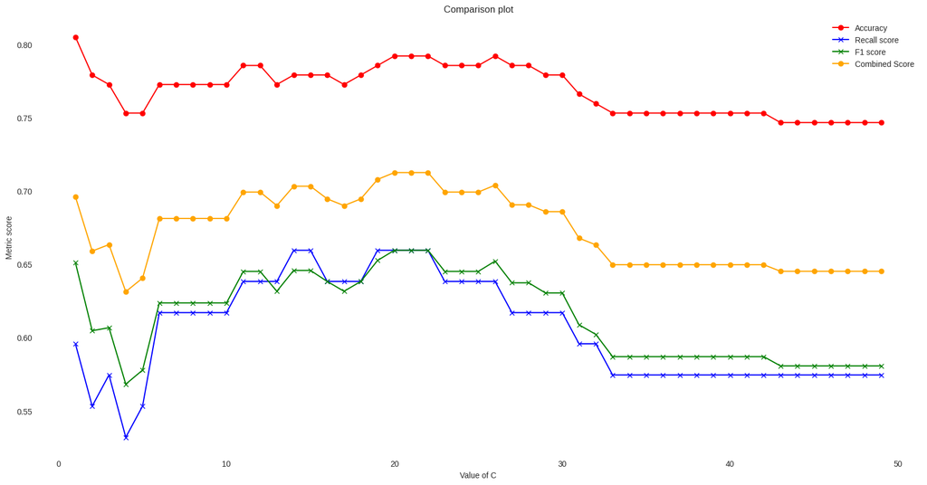

```python
plt.figure(figsize=(20,10))
plt.plot(df_metricas.index,df_metricas['Accuracy'],color='red',marker='o',label='Accuracy')
plt.plot(df_metricas.index,df_metricas['Recall'],color='blue',marker='x',label='Recall score')
plt.plot(df_metricas.index,df_metricas['F1-Score'],color='green',marker='x',label='F1 score')
plt.plot(df_metricas.index,df_metricas['Combined Score'],color='orange',marker='o',label='Combined Score')
plt.legend()
plt.xlabel("Value of C")
plt.ylabel("Metric score")
plt.title("Comparison plot")
plt.show()
```

## **7.8 Encontrar el índice y el Combined Score máximo**

Identificamos la fila en el DataFrame df_metricas que contiene la puntuación combinada más alta. Primero, utiliza df_metricas['Combined Score'].idxmax() para encontrar el índice (etiqueta de fila) de la fila con el valor máximo en la columna 'Combined Score'. Luego, df_metricas.loc[índice] selecciona esa fila completa y la almacena en max_combined_score_row. A continuación, extrae la etiqueta de la fila (que suele ser un valor de C) y la almacena en max_combined_score_index, y finalmente, extrae el valor de la puntuación combinada y lo guarda en max_combined_score. En resumen, este código encuentra la mejor configuración del modelo (en términos de puntuación combinada) y sus métricas asociadas dentro del DataFrame.

```python
max_combined_score_row = df_metricas.loc[df_metricas['Combined Score'].idxmax()]
max_combined_score_index = max_combined_score_row.name
max_combined_score = max_combined_score_row['Combined Score']
```

Identificamos la fila del DataFrame df_metricas que contiene el valor máximo de la puntuación combinada (Combined Score) y extraer la información relevante de esa fila. En primer lugar, utiliza el método idxmax() en la columna Combined Score para obtener el índice de la fila con el valor máximo. Luego, mediante df_metricas.loc[índice], se selecciona esa fila completa y se almacena en la variable max_combined_score_row. A continuación, se extraen el índice de la fila (que generalmente representa un valor del parámetro C) y el valor de la puntuación combinada máxima, almacenándolos en las variables max_combined_score_index y max_combined_score respectivamente. En resumen, este código encuentra la configuración del modelo (valor de C) que produce el mejor rendimiento según la métrica combinada y proporciona tanto el valor de C como la puntuación correspondiente.

```python
# Imprimir los resultados
print("Índice con el máximo Combined Score:", max_combined_score_index)
print("Máximo Combined Score:", max_combined_score)
```

```
Índice con el máximo Combined Score: 20
Máximo Combined Score: 0.7126277977341807
```

El análisis de rendimiento del modelo de clasificación indica que la configuración óptima, con un valor de C igual a 20, alcanzó un Combined Score máximo de 0.713. Este puntaje, que combina precisión, recall y F1-score, sugiere un buen equilibrio entre la capacidad del modelo para identificar correctamente tanto los casos positivos como los negativos, lo que lo convierte en la mejor opción para este problema de clasificación específico.

# **8. Diagrama UML**

[figure not shown]

```python
import pandas as pd
pd.Timestamp.today().strftime('%Y-%m-%d %H:%M:%S') # Se capta la fecha y hora actual
```

```
'2024-06-25 20:06:04'
```

## **APELLIDOS, Nombres:** MOSCOSO CHUMPITAZ, Ricardo Emmanuel

**Fecha:** Sábado 22 de Junio del 2024.